# Precise Bayesian hypothesis testing with the Full Bayesian Significance Test in multidimensional posteriors

Riko Kelter

## Precise Bayesian hypothesis testing with the Full Bayesian Significance Test in multidimensional posteriors

*Author: Riko Kelter*

This vignette explains how to use the Full Bayesian Significance Test (FBST) for Bayesian hypothesis testing of a precise (point-null) hypothesis against its alternative via the e-value in posteriors of dimension larger than one.

```r
library(fbst)
```

Therefore, we use a linear regression model without a predictor, so we are left with the standard deviation $\sigma$ and the intercept, which is the mean parameter $\mu$. Now, we fit the model:

```r
library(rstanarm)
set.seed(42)
mu_true = 0.25
sigma_true = 1
stanData = data.frame(y=rnorm(50,mu_true,sigma_true))
fit1 <- stan_glm(y ~ NULL, data = stanData,
                  family = gaussian(link = "identity"),
                  prior_intercept = normal(0,10),
                  prior_aux = exponential(1),
                  seed = 12345)
```

We can print the fit:

```r
print(fit1)
```

```
#> stan_glm
#>  family:       gaussian [identity]
#>  formula:      y ~ NULL
#>  observations: 50
#>  predictors:   1
#> ------
#>             Median MAD_SD
#> (Intercept) 0.2    0.2
#>
#> Auxiliary parameter(s):
#>       Median MAD_SD
#> sigma 1.2    0.1
#>
#> ------
#> * For help interpreting the printed output see ?print.stanreg
#> * For info on the priors used see ?prior_summary.stanreg
```

We store the posterior draws of $\mu$ and $\sigma$ in a matrix:

```r
posteriorDrawsMatrix = as.matrix(fit1)
head(posteriorDrawsMatrix)
```

```
#>           parameters
#> iterations (Intercept)     sigma
#>       [1,]  0.18938525 1.1507643
#>       [2,]  0.18818783 1.1706089
#>       [3,]  0.07120997 1.1807322
#>       [4,]  0.33424904 1.1841644
#>       [5,]  0.25017576 1.1869898
#>       [6,]  0.30096634 0.9417595
```

Now we call the fbst function:

```r
resFlat = fbst(posteriorDrawsMatrix, nullHypothesisValue=0, dimensionTheta=2, dimensionNullset=1, dim = 2, gridSize = 1000)
summary(resFlat)
```

```
#> Full Bayesian Significance Test for testing a sharp hypothesis against its alternative:
#> Reference function: Flat
#> Hypothesis H_0:Parameter= 0 against its alternative H_1
#> Bayesian e-value against H_0: 0.682
#> Standardized e-value: 0.1300919
```

The plain e-value against the null hypothesis $H_0:\mu=0$ can be accessed as follows:

```r
resFlat$eValue
```

```
#> eValue
#>  0.682
```

In the two-dimensional case, visualization of the results is possible via contour plots or perspective plots:

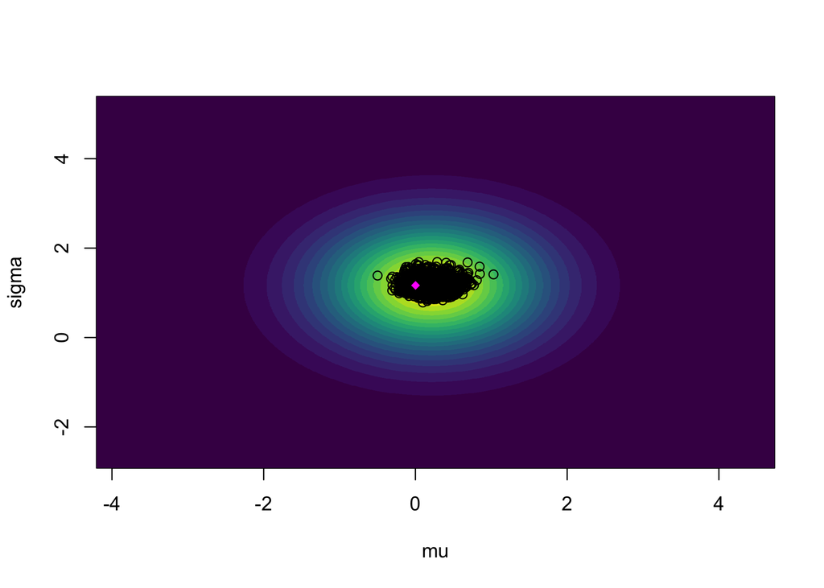

```r
plot(resFlat, type = "contour", parNames=c("mu","sigma"))
```

The above contour plot shows the posterior draws as black points, and the parameter value $(mu_0,\hat{\sigma})$ (magenta point) which maximizes the surprise function under the null set $\Theta_{H_0}:=\{(0,\sigma)|\sigma \in \mathbb{R}_{+}\}$. The e-value against $H_0:\mu=0$ is the integral over the two-dimensional posterior for which the posterior surprise function values
$$\frac{p(\mu,\sigma|y)}{r(\mu,\sigma)}\geq \frac{p(\mu_0,\hat{\sigma}|y)}{r(\mu,\sigma)}$$
Here, we have used a flat reference function $r(\mu,\sigma):=1$, and this is currently the only option in the fbst package when two-dimensional posteriors are used. Note further that as base R does not support multidimensional Gaussian kernel density estimation, the fbst package relies on the ks package for this task, and supports only posteriors up to dimension two.

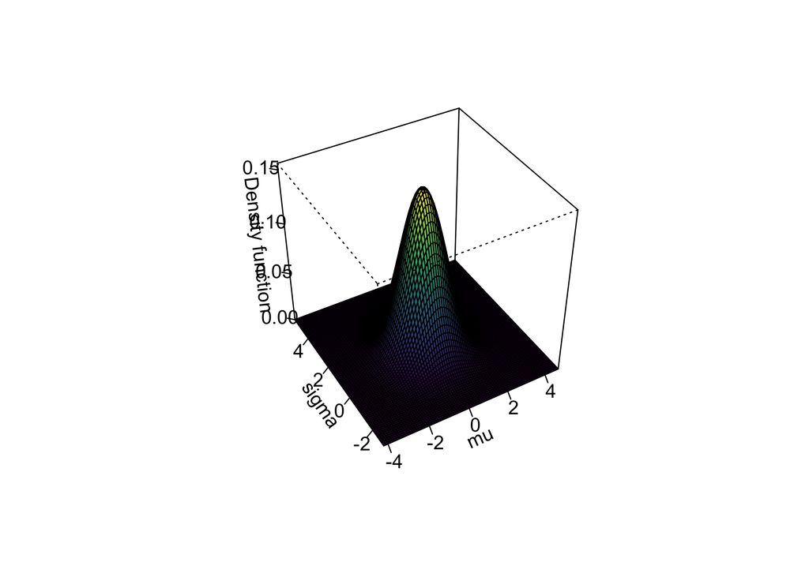

```r
plot(resFlat, type="persp", parNames=c("mu","sigma"))
```

The above plot shows the posterior surface for different values of $(\mu,\sigma)$ based on the simulated data. The evidence against the precise hypothesis $H_0:\mu=0$ is given as

```r
resFlat$eValue
```

```
#> eValue
#>  0.682
```

The evidence against $H_0:\mu=0$ is thus quite large. Note that the standardized e-value can be obtained as in the one-dimensional posterior case:

```r
resFlat$sev_H_0
```

```
#>   sev_H_0
#> 0.1300919
```

## References

Kelter, R. (2022). The Evidence Interval and the Bayesian Evidence Value - On a unified theory for Bayesian hypothesis testing and interval estimation. British Journal of Mathematical and Statistical Psychology (2022). https://doi.org/10.1111/bmsp.12267

Kelter, R. (2021). fbst: An R package for the Full Bayesian Significance Test for testing a sharp null hypothesis against its alternative via the e-value. Behav Res (2021). https://doi.org/10.3758/s13428-021-01613-6

Pereira, C. A. d. B., & Stern, J. M. (2020). The e-value: a fully Bayesian significance measure for precise statistical hypotheses and its research program. São Paulo Journal of Mathematical Sciences, 1–19. https://doi.org/10.1007/s40863-020-00171-7

Kelter, R. (2020). Analysis of Bayesian posterior significance and effect size indices for the two-sample t-test to support reproducible medical research. BMC Medical Research Methodology, 20(88). https://doi.org/https://doi.org/10.1186/s12874-020-00968-2

Rouder, Jeffrey N., Paul L. Speckman, Dongchu Sun, Richard D. Morey, and Geoffrey Iverson. 2009. “Bayesian t tests for accepting and rejecting the null hypothesis.” Psychonomic Bulletin and Review 16 (2): 225–37. https://doi.org/10.3758/PBR.16.2.225